# Analisis Numerico I, Primavera 2025

Análisis Numérico, R. L. Burden y J. D. Faires, ed. 10.

Instructor: Imelda Trejo

Last update: 2025-01-27

```r
rm(list = ls())      # clear memory (removes all the variables from the workspace)
```

# 1 Preliminares

La derivada de la función $f(x)$ en $c$ (si existe) se define como

$$\frac{df(c)}{dx}:=\lim_{x \to c}
\frac{f(x)-f(c)}{x-c}.$$
Si existe la derivada de $f$ en $c$ decimos que $f$ es diferenciables en $c$. También usamos la notación, $f'(c)$,$f''(c)$,…,$f^{n}(c)$ para indicar la primera, segunda, …, $n$-esima derivada de $f$ en $c$.

Denotamos con $C^n(\mathbb{R})$ el conjunto de todas las funciones cuya derivada $n$-enesima existe y es continua en todos los números reales. $C^\infty(\mathbb{R})$ denota el conjunto de todas la funciones infinitamente diferenciables y cuyas derivadas son continuas.

Ejemplo. $f(x)=e^{x}\in C^\infty(\mathbb{R})$.

Similarmente, $C^n([a,b])$ denota el conjunto de funciones cuya derivada $n$-esima existe en $(a,b)$ y es continua en $[a,b]$.

**Teorema del Valor Medio (TVM):** Supongamos que $f\in C[a,b]$ y que $f'(x)$ existe para todo $x\in (a,b)$. Entonces existe un nuero $c$ tal que
$$f'(c)=\frac{f(b)-f(a)}{b-a}.$$
Relacióna las pendientes de la recta tangente y secante.

**Teorema de Rolle:** Supongamos que $f\in C[a,b]$ y que $f'(x)$ existe para todo $x\in (a,b)$. Si $f(a)=f(b)$,  
Entonces existe un número $c$ tal que $f'(c)=0$. Util para asegurar máximos o mínimos.

**Teorema de Weierstrass:** Toda función real y continua en un compacto alcanza su máximo y mínimo.

**Teorema del Valor Intermedio (TVI) o de Bolzano:** Supongamos que $f\in C[a,b]$ y que $L$ es cualquier numero entre $a$ y $b$. Entonces existe un número $c$ tal que $f(c)=L$.

Util para demostrar la existencia de raices de una función.

## 1.1 Teorema de Taylor y el Resto

Teorema de Taylor con la fórmula de Lagrange para el resto.

**Teorema 1** Si $f\in C^n[a,b]$ y si $f^{n+1}(x)$ existe para todo $x\in (a,b)$. Entonces para cualesquier puntos $c$ y $x$ en $[a,b]$,
existe un punto $\xi$ entre $c$ y $x$ tal que:
$$f(x)= \sum^{n}_{k=0}\frac{1}{k!}
f^{(k)}(c)\left(x-c\right)^k+R_{n}(x)$$
donde,
$$E_n(x)=\frac{1}{(n+1)!}f^{(n+1)}(\xi)(x-c)^{n+1}.$$

Una función ‘suficientemente’ suave puede ser apróximada por un polinomio.

**Ejemplo:** Compute the Taylor series of $f(x)=ln(x)$ where $a=1$, $b=2$ and $c=1$. Then compute $ln(2)$.

Escribir la serie en el pizarron.

El Polinomio de Taylor de grado cinco para $f(x)=ln(x)$ al rededor de 1 es:
$$P_5(x)=(x-1)-\frac{1}{2}(x-1)^2+\frac{1}{3}(x-1)^3-\frac{1}{4}(x-1)^4+\frac{1}{5}(x-1)^5$$

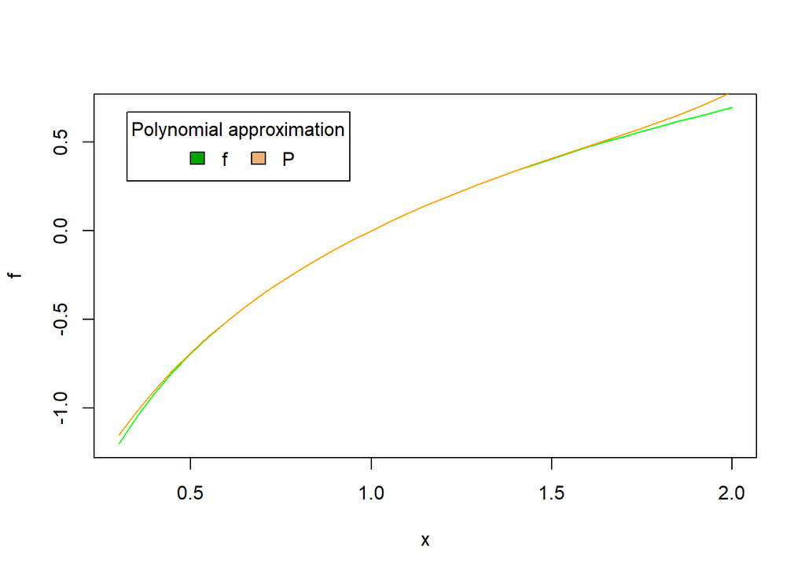

```r
x  <- seq(0.3, 2, 0.05)
f <- log(x)
P <- (x-1)-(x-1)**2/2+(x-1)^3/3-(x-1)^4/4+(x-1)^5/5
plot(x,f,type="l",col="green")
lines(x,P,col="orange")
legend("topleft", inset=.05, title="Polynomial approximation",
  c("f","P"), fill=terrain.colors(3), horiz=TRUE)
```

Nota: la estimación es local.

Calcular $\ln(2)$.
$$ln(2)=
1-\frac{1}{2}+\frac{1}{3}-\frac{1}{4}+...+\frac{(-1)^n}{n}+R_n(2).$$
Entonces para calcular $\ln(2)$ con una **precisión** de $10^8$, requerimos que el resto
$$|R_n(2)|\leq \frac{1}{n+1}\leq
10^{-8}.$$
Es decir requerimos usar más de 100 millones ($n\geq 10^8$) de términos de la serie de Taylor para obtener dicha precisión. Cuando codifiquemos tener cuidado con las tolerancias, ver páginas 36 del archivo pdf, **Sección 1.3 Algoritmos y convergencia.**

Ejercicios: Calcular la serie de Taylor para $e^x$, $\cos(x)$, $\frac{1}{x-1}$ alrededor de $x_0=0$. Escribe los correspondientes polinomios de Taylor y restos de grado $n$.

## 1.3 Orden de convergencia

Velocidad de convergencia de sucesiones y límites.

### 1.3.1 Motivación:

Para las siguientes series convergentes, calcular los primeros 10 términos de la sucesión.

$$e=\lim_{n\to\infty}
\large(1+\frac{1}{n}\large)^{n}\approx 2.71828182845905$$

```r
for (n in 1:10) {
  if(n%%1==0){
    print((1+1/n)^n)
  }
}
```

```
## [1] 2
## [1] 2.25
## [1] 2.37037
## [1] 2.441406
## [1] 2.48832
## [1] 2.521626
## [1] 2.5465
## [1] 2.565785
## [1] 2.581175
## [1] 2.593742
```

2. Sea $x_1=2$, y
   $$x_{n+1}=\frac{1}{2}x_n+\frac{1}{x_n}.$$
   Entonces
   $$\lim_{n\to\infty}{x_n}=\sqrt{2}\approx
   1.41421356.$$

```r
recursiva <- function (x) {
  r=x/2+1/x
  return(r)
}

xnew<-2
for (n in 1:10) {
  print(round(xnew, digits = 10))
  #print(xnew)
  xnew=recursiva(xnew)
}
```

```
## [1] 2
## [1] 1.5
## [1] 1.416667
## [1] 1.414216
## [1] 1.414214
## [1] 1.414214
## [1] 1.414214
## [1] 1.414214
## [1] 1.414214
## [1] 1.414214
```

El segundo ejemplo converge más rápido a su límite. Para darnos una idea sobre la rapidez de convergencia en sucesiones y límites usaremos la notación de O grande y o pequeña.

### 1.3.2 Natación O grande y o pequeña (tasas de convergencia).

**Pagina 40 del archivo pdf digital**

Definición 1.18.

Sea $\{x_n\}$ una sucesión que converge a $x$ y sea $\{y_n\}$ una sucesión que converge a cero. Se dice que $\{x_n\}$ tiene un orden de convergencia $O(y_n)$ si existe una constante $K>0$ y un real $r$ tal que
$$|x_n-x|\leq K|y_n|$$
para todo $n>r$. Se escribe $x_n=x+O(y_n)$.

Sea $\lim_{x\to 0}f(x)=L$ y $\lim_{x\to 0}g(x)=0$. Diremos que el orden de convergencia del limite es $O(g(x))$ si existe una constante $K>0$ tal que
$$|f(x)-L|\leq K |g(x)|$$
para $x$ sufucientemente pequeño. Se escribe $f(x)=L+O(g(x))$.

Ver ejemplos 2 y 3 del libro.
$$\cos(h)
+\frac{2}{h^2} = 1 + O(h^4).$$

Ejemplo 4. Hallar el orden del límite
$$\lim_{h \to 0} \frac{\sin (h)}{h}=1.$$
Solución: El orden del límite es $O(h^2)$.

Escribimos $x_n=o(y_n)$ si $y_n\neq0$ y
$$\lim_{n\to\infty}\frac{x_n}{y_n}=0,$$
es decir $y_n$ convege más rápido que $x_n$.

Ejemplo. $\frac{1}{n\ln(n)}=o(1/n)$.

## 1.2 Medidas del error, error de redondeo, y aritmética de una computadora.

Ver p’agina 25: https://heavyphysicsblog.wordpress.com/wp-content/uploads/2019/06/analisis-numerico-burden-faires-10ed.pdf

Los *métodos numéricos* son una serie de instrucciones o algoritmos matemáticos diseñados para obtener **aproximaciones** a valores, especialmente cuando las soluciones exactas no son posibles o son difíciles de calcular. El **análisis numérico** es la base teórica de los métodos numéricos.

El **error**, diferencia entre el valor numérico aproximado y el valor exácto, en los métodos numéricos puede surgir por el manejo finito de memoria de una computadora, errores de redondeo y truncamiento, por el modelo usado al resolver un problemas (modelo aproximar una inegral con una suma finita, aproximar el límite de una sucesión con un numero finito de iteraciones), ver https://chatgpt.com/c/67996035-0e50-8004-ade2-3fa56665434f

### Características principales del análisis numérico:

- **Estudio de errores:** Analiza la precisión de los métodos y cuantifica los errores involucrados en las aproximaciones, diferenciando entre errores de truncamiento y de redondeo.
- **Estabilidad:** Evalúa como los errores se *propagan* durante los cálculos y si afectan significativamente el resultado final.
- **Convergencia:** Determina si las soluciones aproximadas generadas por un método *se acercan a la solución exacta* conforme se incrementa el número de iteraciones o se refina el proceso.
- **Eficiencia:** Busca *optimizar* el costo computacional y el *tiempo* requerido para encontrar una solución, garantizando un balance entre precisión y recursos.

### 1.2.1 Aritmética de una computadora

#### Motivaci’on:

1. ¿Quién es mayor 9.9 o 9.11?
2. ¿Cuál es el resultado de la resta 9.11 menos 9.9?
3. Hacer las mismas preguntas a Chatgpt.

https://chatgpt.com/c/677c9cac-0fec-8004-a7a8-14f4f01574c2

4. Realizar la resta en python? o pedir a chatgpt que use python
5. ¿Por qué hay imprecisión en python y en algunos otros programas de programación? C’omo chatgpt hizo la comparaci’on?

```r
9.11-9.9
```

```
## [1] -0.79
```

### Manejo finito de memoria.

El sistema numérico que emplea la computadora es el sistema de **número punto flotante**.

https://chatgpt.com/c/677b33ff-0da4-8004-9873-a084bc3ab284

La forma general de un número en punto flotante es:

$$N'umero =
Signo×Mantisa×Base^{Exponente}$$
Normalmente la base es 10 o 2 (notación cient’ifica o binaria).

Ejemplo (Notación cient’ifica)

$732.5051=0.7325051\times10^3$

$-0.005612=-0.5612\times10^{-2}$

En general,

$$x=\pm r \times 10^n$$

donde $r$ es numero entre $\frac{1}{10}\leq r<1$. Si $x=0$, entonces $r=0$. Entodos los otros casos podemos ajustar $n$ en el rango de $r$ dado.

Ejemplo (Notación binaria)

$$x=\pm q \times 2^n$$
donde $\frac{1}{2}\leq q<1$.

en ambos casos $r$ y $q$ es la **mantisa**.

Denotemos con $fl(x)$ la función punto flotante, esto es para todo real $x$:
$$fl(x)=0.c_1c_2c_3...c_k Base^n$$
donde $n$, el exponete, es un entero (positivo, negativo, o zero).

Nota: la funci’on $fl(x)$ termina la mantisa de $x$ en los $k$ dígitos, decimales o binarios. Existen dos maneras comunes para realizar esta terminación: **redondeo** o **truncamiento**.

Ejemplo, el n’umero punto flotante de $1/3$ con cuatro d’igitos decimales usando truncamiento o redondeo es,

$$fl(\frac{1}{3})=0.3333$$
.

### Representacion en la computadora.

En computación, los números en punto flotante suelen representarse utilizando estándares como el *IEEE 754*, que define la aritm’etica binaria y reglas para manejar operaciones. Por ejemplo: Un número de 32 bits (punto flotante simple precisión) se divide en:

```
    1 bit para el signo.
    8 bits para el exponente.
    23 bits para la mantisa.
```

Un número de 64 bits (doble precisión) utiliza más bits para mayor precisión, ver libro.

En ambos casos, 32 o 64 bits, la mantisa y exponente son finitos, por lo tanto las operaciones, aritm’etica en las computadoras, se efectuan usando la funci’on punto flontante $fl(x)$.

Nota: N’umeros muy pequenos o muy grandes tampoco pueden ser representados (underflow and overflow, ver libro).

*ver el libro; la aritm’etica de las computadoras, es decir la aritm’etica usando la funci’on $fl(x)$.*

### 1.2.2 Teoría de errores

Se pueden medir por ejemplo con el error absoluto y relativo.

Supongamos que $p$ aproxima a $p^*$, $p \approx p^*$.

El error absoluto es:
$$|p-p^*|$$

El error relativo es:
$$\frac{|p-p^*|}{|p|},$$
$p\neq 0$.

Las medidas de error se usan para evaluar y cuantificar la **precisión** de los métodos numéricos. Una menor magnitud de error (se recomienda usar el error relativo) implica un método más preciso y confiable.

Conceptos de medidas de error, tolerancia y precisión, métodos numéricos estables, métodos numéricos bien y mal condicionados.

ver: https://chatgpt.com/c/679954af-69d0-8004-91d5-767c4955fdfa

Numero de digitos significativos